# Case_Study_Group_25

## 3.5 Graphs for the important features

1. Step: Create a function, which first checks whether the relevant information is included in the dataset, here the column “Fehlerhaft”. Afterwards make sure to exclude all datasets where the unique number of observations = 1.
2. Step: Apply the created function the list of variables

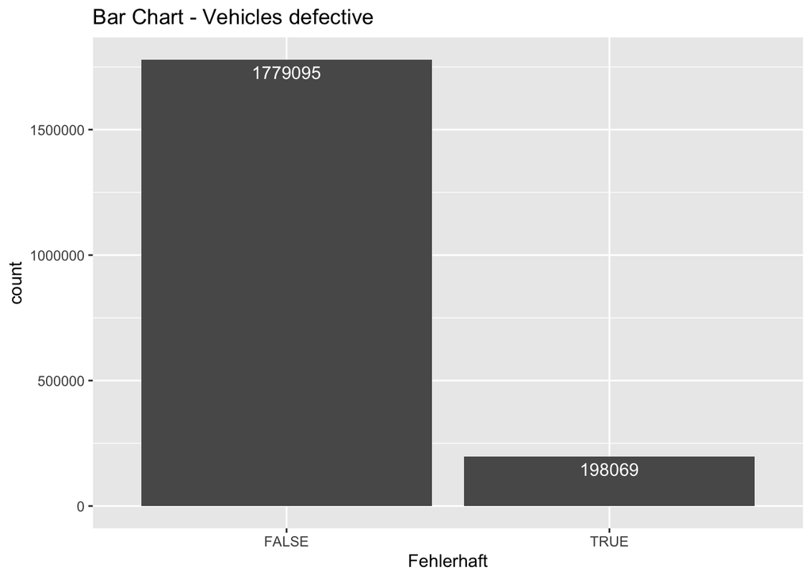

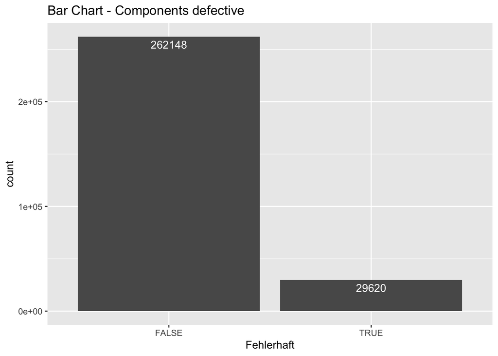

```r
# 1. Step
plot_defective <- function(dataframe){
  if("Fehlerhaft" %in% colnames(dataframe)){
    if(length(dataframe[["Fehlerhaft"]]) != length(which(dataframe[["Fehlerhaft"]] == TRUE))){
      if("ID_Fahrzeug" %in% colnames(dataframe)){
        ggplot(dataframe, aes(x=Fehlerhaft)) +
        geom_bar() +
        geom_text(aes(label=..count..), stat="count", vjust= 1.5, colour= "white") +
        ggtitle("Bar Chart - Vehicles defective")
      }else{
         ggplot(dataframe, aes(x=Fehlerhaft)) +
        geom_bar() +
        geom_text(aes(label=..count..), stat="count", vjust= 1.5, colour= "white") +
        ggtitle("Bar Chart - Components defective")
      }
    }
  }
}

# 2. Step
lapply(var_list, plot_defective)
```

# 4 Creating the final dataset

1. Step: Join the junction table the respective data tables to obtain the ID relevant to join with other data tables
2. Step: Connect the smallest unit to the next higher unit, Parts => Components
3. Step: Join the component & part data with the vehicle data and create a column that indicates whether one of these units is defective
4. Step: Join the car registrations and geo data to obtain the geographical coordinates for the communities
5. Step: Bring everything together in one dataframe and calculate the distance between the communities and the center of Berlin (Long/Lat obtained from this website: https://www.umingo.de/deutschland/berlin/)

```r
# 1. Step
joined_vehicles <- var_list[["vehicle"]] %>%
                    inner_join(var_list[["junction_vehicle"]], by= c("ID_Fahrzeug" = "ID_Fahrzeug"))

joined_components <- var_list[["components"]] %>%
                      inner_join(var_list[["junction_component"]], by= c("ID_Motor" = "ID_K1DI1"), suffix= c("", "_junction"))

# 2. Step
joined_components_parts <- joined_components %>%
                              left_join(var_list[["parts_t1"]], by=c("ID_T1" = "ID_T01")) %>%
                              left_join(var_list[["parts_t2"]], by=c("ID_T2" = "ID_T02")) %>%
                              left_join(var_list[["parts_t5"]], by=c("ID_T5" = "ID_T05")) %>%
                              left_join(var_list[["parts_t6"]], by=c("ID_T6" = "ID_T06")) %>%
                              rename(Fehlerhaft_component = Fehlerhaft.x) %>%
                              rename(Fehlerhaft_T1 = Fehlerhaft.y) %>%
                              rename(Fehlerhaft_T2 = Fehlerhaft.x.x) %>%
                              rename(Fehlerhaft_T5 = Fehlerhaft.y.y) %>%
                              rename(Fehlerhaft_T6 = Fehlerhaft) %>%
                              mutate(Fehlerhaft_T1 = replace_na(Fehlerhaft_T1, FALSE)) %>%
                              mutate(Fehlerhaft_T2 = replace_na(Fehlerhaft_T2, FALSE)) %>%
                              mutate(Fehlerhaft_T5 = replace_na(Fehlerhaft_T5, FALSE)) %>%
                              mutate(Fehlerhaft_T6 = replace_na(Fehlerhaft_T6, FALSE))
# 3. Step
defective_vehicle_to_parts <- joined_vehicles %>%
                                inner_join(joined_components_parts, by=c("ID_Motor" = "ID_Motor")) %>%
                                rename(Fehlerhaft_vehicle = Fehlerhaft) %>%
                                mutate(Defect = ifelse(Fehlerhaft_vehicle == TRUE, TRUE,
                                                       ifelse(Fehlerhaft_component == TRUE, TRUE,
                                                              ifelse(Fehlerhaft_T1 == TRUE |
                                                                     Fehlerhaft_T2 == TRUE |
                                                                     Fehlerhaft_T5 == TRUE |
                                                                     Fehlerhaft_T6 == TRUE, TRUE, FALSE))))

# 4.Step
car_registration_with_geo <- var_list[["car_registrations"]] %>%
                              left_join(var_list[["geo_data"]], by= c("Gemeinden" = "Gemeinde"))

# 5. Step
entire_defective_data <- defective_vehicle_to_parts %>%
                          inner_join(car_registration_with_geo, by = c("ID_Fahrzeug" = "IDNummer")) %>%
                          mutate(Distance_KM = distHaversine(cbind(Laengengrad, Breitengrad), cbind(13.3777, 52.5162))/1000) %>%
                          select("ID_Fahrzeug", "Defect", "Gemeinden", "Laengengrad", "Breitengrad", "Distance_KM")

write_csv(entire_defective_data, file = "Final_dataset_group_25.csv")
```

# 5 Evaluation & Results

The result of the case-study can be seen in our shiny application. We chose just a lean layout including the given specifications because we want to set the main focus to the other tasks. To navigate through our tabs we used the navbarpage to get a top level navigation bar.

## 5.1 Map

The first tab is the map, showing variably definable concentric circles around Berlin. By clicking the marker a popup appears displaying the number of registered vehicles in the “Gemeinde” and a plot showing the vehicles with diesel engines affected by the driving ban in relation to those not affected. It is our fist tab because you get a really good overview by getting insights with the popups at the same time. This helps the user to understand the magnitude of the problem and to classify its importance.

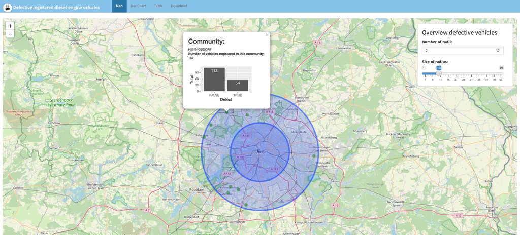

Shiny App - Map

## 5.2 Barplot

The second tab is the interactive barplot. For each radius, the number of affected diesel-engined vehicles registered within that radius in relation to the unaffected vehicles is shown in the graphic. The number and the size of the radius can be chosen interactively. Here, the user gets an aggregated view to asses the full extent.

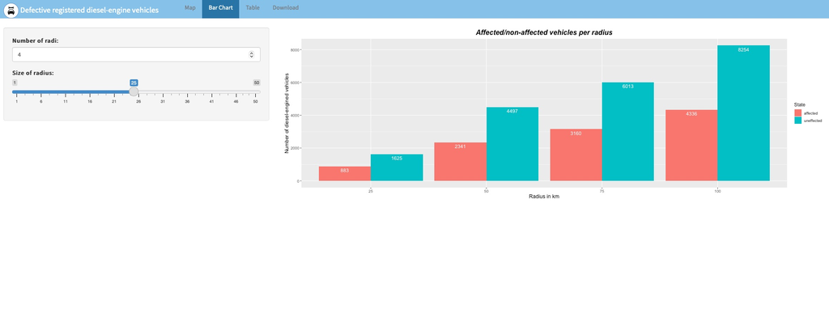

Shiny App - Bar Chart

## 5.3 Table

In this tab we display the underlying data as table. We decided to show these attributes in the table because the user is able to get the most important facts at a glance. Now it is feasible to get an exact insight on the data to prove the visuals.

All in all the application helps to visualize the case and supports the user to make a decision in an otherwise very confusing quantity of data.

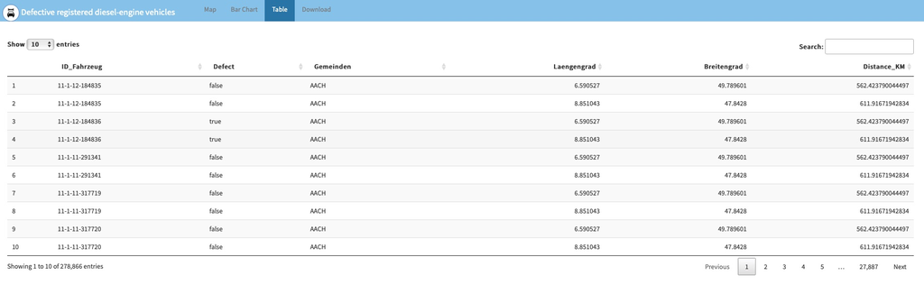

Shiny App - Table

## 5.4 Download

The next tab has the purpose to download the dataset in the formats csv or xlsx. It is important to offer the user the possibility to choose between these filetypes because a csv is operating system independent and xlsx is just usable with the fitting application. On the other site, it is quite common and very user friendly. Moreover, the download allows the user to make their own evaluations and analyses with the data if necessary.

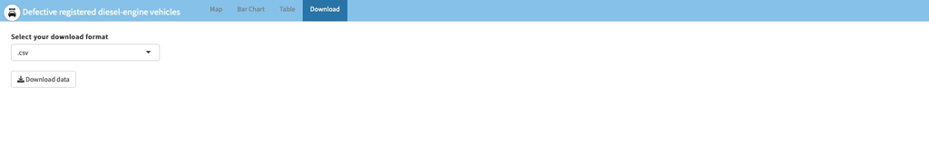

Shiny App - Download